# Wrangling your data 🤠, recitation

Jessica Cooperstone

Week 4

## Introduction

Today you are going to be practicing what you learned in the wrangling lesson. The more you practice modifying your data the easier it becomes. Remember, there are many ways to accomplish the same outcome. In the recitation solutions, I will show you a few different ways to answer the prompts and you can see how they differ, and use the ones that resonate with you.

```r
library(tidyverse)
```

### Load data

To practice, we will be using some data I have extracted from [Gapminder](https://www.gapminder.org/). I am linking to two files that you can download to your computer, and then read them in like we learned in class.

- Data on the happiness index for many countries for many years
- Data on the life expectancy for many countries for many years

```r
# read in happiness data from your computer
# mine has the path below since i have a subfolder called data where
# the happiness data is living
happiness <- read_csv("data/hapiscore_whr.csv")
# read in life expectancy data from your computer
life_expectancy <- read_csv("data/life_expectancy.csv")
```

## Explore your data

Write some code that lets you explore that is in these two datasets.

```r
# see data structure with glimpse
glimpse(happiness)
```

```
## Rows: 163
## Columns: 19
## $ country <chr> "Afghanistan", "Angola", "Albania", "United Arab Emirates", "A…
## $ `2005`  <dbl> NA, NA, NA, NA, NA, NA, 73.4, NA, NA, NA, 72.6, NA, NA, NA, NA…
## $ `2006`  <dbl> NA, NA, NA, 67.3, 63.1, 42.9, NA, 71.2, 47.3, NA, NA, 33.3, 38…
## $ `2007`  <dbl> NA, NA, 46.3, NA, 60.7, 48.8, 72.8, NA, 45.7, NA, 72.2, NA, 40…
## $ `2008`  <dbl> 37.2, NA, NA, NA, 59.6, 46.5, 72.5, 71.8, 48.2, 35.6, 71.2, 36…
## $ `2009`  <dbl> 44.0, NA, 54.9, 68.7, 64.2, 41.8, NA, NA, 45.7, 37.9, NA, NA, …
## $ `2010`  <dbl> 47.6, NA, 52.7, 71.0, 64.4, 43.7, 74.5, 73.0, 42.2, NA, 68.5, …
## $ `2011`  <dbl> 38.3, 55.9, 58.7, 71.2, 67.8, 42.6, 74.1, 74.7, 46.8, 37.1, 71…
## $ `2012`  <dbl> 37.8, 43.6, 55.1, 72.2, 64.7, 43.2, 72.0, 74.0, 49.1, NA, 69.3…
## $ `2013`  <dbl> 35.7, 39.4, 45.5, 66.2, 65.8, 42.8, 73.6, 75.0, 54.8, NA, 71.0…
## $ `2014`  <dbl> 31.3, 38.0, 48.1, 65.4, 66.7, 44.5, 72.9, 69.5, 52.5, 29.1, 68…
## $ `2015`  <dbl> 39.8, NA, 46.1, 65.7, 67.0, 43.5, 73.1, 70.8, 51.5, NA, 69.0, …
## $ `2016`  <dbl> 42.2, NA, 45.1, 68.3, 64.3, 43.3, 72.5, 70.5, 53.0, NA, 69.5, …
## $ `2017`  <dbl> 26.6, NA, 46.4, 70.4, 60.4, 42.9, 72.6, 72.9, 51.5, NA, 69.3, …
## $ `2018`  <dbl> 26.9, NA, 50.0, 66.0, 57.9, 50.6, 71.8, 74.0, 51.7, 37.8, 68.9…
## $ `2019`  <dbl> 23.8, NA, 50.0, 67.1, 60.9, 54.9, 72.3, 72.0, 51.7, NA, 67.7, …
## $ `2020`  <dbl> NA, NA, 53.6, 64.6, 59.0, NA, 71.4, 72.1, NA, NA, 68.4, 44.1, …
## $ `2021`  <dbl> 24.4, NA, 52.5, 67.3, 59.1, 53.0, 71.1, 70.8, NA, NA, 68.8, 44…
## $ `2022`  <dbl> 18.6, NA, 52.8, 65.7, 60.2, 53.4, 71.0, 71.0, NA, NA, 68.6, 43…
```

```r
# look at all columns and first 6 rows with head
head(happiness)
```

```
## # A tibble: 6 × 19
##   country  `2005` `2006` `2007` `2008` `2009` `2010` `2011` `2012` `2013` `2014`
##   <chr>     <dbl>  <dbl>  <dbl>  <dbl>  <dbl>  <dbl>  <dbl>  <dbl>  <dbl>  <dbl>
## 1 Afghani…     NA   NA     NA     37.2   44     47.6   38.3   37.8   35.7   31.3
## 2 Angola       NA   NA     NA     NA     NA     NA     55.9   43.6   39.4   38
## 3 Albania      NA   NA     46.3   NA     54.9   52.7   58.7   55.1   45.5   48.1
## 4 United …     NA   67.3   NA     NA     68.7   71     71.2   72.2   66.2   65.4
## 5 Argenti…     NA   63.1   60.7   59.6   64.2   64.4   67.8   64.7   65.8   66.7
## 6 Armenia      NA   42.9   48.8   46.5   41.8   43.7   42.6   43.2   42.8   44.5
## # ℹ 8 more variables: `2015` <dbl>, `2016` <dbl>, `2017` <dbl>, `2018` <dbl>,
## #   `2019` <dbl>, `2020` <dbl>, `2021` <dbl>, `2022` <dbl>
```

```r
# this will open the file for you to look through in R
# View(happiness)
```

```r
# see data structure with glimpse
glimpse(life_expectancy)
```

```
## Rows: 195
## Columns: 302
## $ country <chr> "Afghanistan", "Angola", "Albania", "Andorra", "United Arab Em…
## $ `1800`  <dbl> 28.2, 27.0, 35.4, NA, 30.7, 33.2, 34.0, 33.5, 34.0, 34.4, 29.2…
## $ `1801`  <dbl> 28.2, 27.0, 35.4, NA, 30.7, 33.2, 34.0, 33.5, 34.0, 34.4, 29.2…
## $ `1802`  <dbl> 28.2, 27.0, 35.4, NA, 30.7, 33.2, 34.0, 33.5, 34.0, 34.4, 29.2…
## $ `1803`  <dbl> 28.2, 27.0, 35.4, NA, 30.7, 33.2, 34.0, 33.5, 34.0, 34.4, 29.2…
## $ `1804`  <dbl> 28.2, 27.0, 35.4, NA, 30.7, 33.2, 34.0, 33.5, 34.0, 34.4, 29.2…
## $ `1805`  <dbl> 28.2, 27.0, 35.4, NA, 30.7, 33.2, 34.0, 33.5, 34.0, 34.4, 29.2…
## $ `1806`  <dbl> 28.1, 27.0, 35.4, NA, 30.7, 33.2, 34.0, 33.5, 34.0, 34.4, 29.2…
## $ `1807`  <dbl> 28.1, 27.0, 35.4, NA, 30.7, 33.2, 34.0, 33.5, 34.0, 34.4, 29.2…
## $ `1808`  <dbl> 28.1, 27.0, 35.4, NA, 30.7, 33.2, 34.0, 33.5, 34.0, 34.4, 29.2…
## $ `1809`  <dbl> 28.1, 27.0, 35.4, NA, 30.7, 33.2, 34.0, 33.5, 34.0, 34.4, 29.2…
## $ `1810`  <dbl> 28.1, 27.0, 35.4, NA, 30.7, 33.2, 34.0, 33.5, 34.0, 34.4, 29.2…
## $ `1811`  <dbl> 28.1, 27.0, 35.4, NA, 30.7, 33.2, 34.0, 33.5, 34.0, 34.4, 29.2…
```

[output cut: 289 more lines]

```r
# look at all columns and first 6 rows with head
head(life_expectancy)
```

```
## # A tibble: 6 × 302
##   country  `1800` `1801` `1802` `1803` `1804` `1805` `1806` `1807` `1808` `1809`
##   <chr>     <dbl>  <dbl>  <dbl>  <dbl>  <dbl>  <dbl>  <dbl>  <dbl>  <dbl>  <dbl>
## 1 Afghani…   28.2   28.2   28.2   28.2   28.2   28.2   28.1   28.1   28.1   28.1
## 2 Angola     27     27     27     27     27     27     27     27     27     27
## 3 Albania    35.4   35.4   35.4   35.4   35.4   35.4   35.4   35.4   35.4   35.4
## 4 Andorra    NA     NA     NA     NA     NA     NA     NA     NA     NA     NA
## 5 United …   30.7   30.7   30.7   30.7   30.7   30.7   30.7   30.7   30.7   30.7
## 6 Argenti…   33.2   33.2   33.2   33.2   33.2   33.2   33.2   33.2   33.2   33.2
## # ℹ 291 more variables: `1810` <dbl>, `1811` <dbl>, `1812` <dbl>, `1813` <dbl>,
## #   `1814` <dbl>, `1815` <dbl>, `1816` <dbl>, `1817` <dbl>, `1818` <dbl>,
## #   `1819` <dbl>, `1820` <dbl>, `1821` <dbl>, `1822` <dbl>, `1823` <dbl>,
## #   `1824` <dbl>, `1825` <dbl>, `1826` <dbl>, `1827` <dbl>, `1828` <dbl>,
## #   `1829` <dbl>, `1830` <dbl>, `1831` <dbl>, `1832` <dbl>, `1833` <dbl>,
## #   `1834` <dbl>, `1835` <dbl>, `1836` <dbl>, `1837` <dbl>, `1838` <dbl>,
## #   `1839` <dbl>, `1840` <dbl>, `1841` <dbl>, `1842` <dbl>, `1843` <dbl>, …
```

```r
# this will open the file for you to look through in R
# View(life_expectancy)
```

How many observations there in each dataset?

```r
dim(happiness)
```

```
## [1] 163  19
```

```r
dim(life_expectancy)
```

```
## [1] 195 302
```

What years do the data contain information for?

```r
happiness_long <- happiness |>
  pivot_longer(cols = !country,
               names_to = "year",
               values_to = "happy_value")

happiness_long |>
  summarize(min_year = min(year),
            max_year = max(year))
```

```
## # A tibble: 1 × 2
##   min_year max_year
##   <chr>    <chr>
## 1 2005     2022
```

```r
life_expectancy_long <- life_expectancy |>
  pivot_longer(cols = !country,
               names_to = "year",
               values_to = "life_exp")

life_expectancy_long |>
  summarize(min_year = min(year),
            max_year = max(year))
```

```
## # A tibble: 1 × 2
##   min_year max_year
##   <chr>    <chr>
## 1 1800     2100
```

## Modifying data

Create a new dataset for life_expectancy that only includes observed data (i.e., remove the projected data after 2022).

```r
life_expectancy_actual <- life_expectancy_long |>
  filter(year <= 2022)

life_expectancy_actual <- life_expectancy |>
  select(country, num_range(prefix = "", # since there is no prefix here
                            range = 1800:2022))
```

## Calculating summaries

What country has the highest average happiness index in 2022?

```r
# highest happiness is 2022
# note you can have columns that use non-standard R naming convention
# like here where columns are numbers
# but you need to refer to them surrounded by backticks
happiness |>
  select(country, `2022`) |>
  arrange(desc(`2022`))
```

```
## # A tibble: 163 × 2
##    country     `2022`
##    <chr>        <dbl>
##  1 Finland       78
##  2 Denmark       75.9
##  3 Iceland       75.3
##  4 Israel        74.7
##  5 Netherlands   74
##  6 Sweden        74
##  7 Norway        73.2
##  8 Switzerland   72.4
##  9 Luxembourg    72.3
## 10 New Zealand   71.2
## # ℹ 153 more rows
```

```r
# or we could use clean_names
happiness |>
  janitor::clean_names() |>
  select(country, x2022) |>
  arrange(desc(x2022))
```

```
## # A tibble: 163 × 2
##    country     x2022
##    <chr>       <dbl>
##  1 Finland      78
##  2 Denmark      75.9
##  3 Iceland      75.3
##  4 Israel       74.7
##  5 Netherlands  74
##  6 Sweden       74
##  7 Norway       73.2
##  8 Switzerland  72.4
##  9 Luxembourg   72.3
## 10 New Zealand  71.2
## # ℹ 153 more rows
```

```r
happiness %>%
  select(country, `2022`) %>%
  slice_max(`2022`)
```

```
## # A tibble: 1 × 2
##   country `2022`
##   <chr>    <dbl>
## 1 Finland     78
```

What about overall average highest index?

```r
# if you want to calculate and have missing values
# you need to remove them as the default is to not

# using select in rowMeans
happiness |>
  mutate(mean_happiness = rowMeans(select(happiness, -country),
                                          na.rm = TRUE)) |>
  arrange(desc(mean_happiness))
```

```
## # A tibble: 163 × 20
##    country `2005` `2006` `2007` `2008` `2009` `2010` `2011` `2012` `2013` `2014`
##    <chr>    <dbl>  <dbl>  <dbl>  <dbl>  <dbl>  <dbl>  <dbl>  <dbl>  <dbl>  <dbl>
##  1 Denmark   80.2   NA     78.3   79.7   76.8   77.7   77.9   75.2   75.9   75.1
##  2 Finland   NA     76.7   NA     76.7   NA     73.9   73.5   74.2   74.5   73.8
##  3 Switze…   NA     74.7   NA     NA     75.3   NA     NA     77.8   NA     74.9
##  4 Norway    NA     74.2   NA     76.3   NA     NA     NA     76.8   NA     74.4
##  5 Iceland   NA     NA     NA     68.9   NA     NA     NA     75.9   75     NA
##  6 Nether…   74.6   NA     74.5   76.3   NA     75     75.6   74.7   74.1   73.2
##  7 Sweden    73.8   NA     72.4   75.2   72.7   75     73.8   75.6   74.3   72.4
##  8 Canada    74.2   NA     74.8   74.9   74.9   76.5   74.3   74.2   75.9   73
##  9 New Ze…   NA     73     76     73.8   NA     72.2   71.9   72.5   72.8   73.1
## 10 Austra…   73.4   NA     72.8   72.5   NA     74.5   74.1   72     73.6   72.9
## # ℹ 153 more rows
## # ℹ 9 more variables: `2015` <dbl>, `2016` <dbl>, `2017` <dbl>, `2018` <dbl>,
## #   `2019` <dbl>, `2020` <dbl>, `2021` <dbl>, `2022` <dbl>,
## #   mean_happiness <dbl>
```

```r
rowMeans(happiness[,-1], na.rm = TRUE)
```

```
##   [1] 33.87143 44.22500 50.52000 67.80667 62.69412 46.15000 72.60000 72.22000
##   [9] 49.40714 35.50000 69.66250 41.03571 42.58125 46.89412 46.98571 60.15833
##  [17] 52.58000 55.71429 62.05000 57.20588 65.56471 51.96667 39.53077 35.16000
##  [25] 73.27647 75.04167 63.60000 51.41176 46.88182 46.62353 42.21111 46.09231
##  [33] 61.56471 38.88571 70.51765 54.20000 61.18667 66.35000 68.40000 48.25000
##  [41] 76.75882 52.84706 53.72727 57.12353 44.79412 65.03529 57.41875 43.69000
##  [49] 76.23333 66.68824 45.75833 69.08235 43.67647 47.80588 43.32500 46.20000
##  [57] 56.08750 62.47333 59.90000 54.26923 54.77500 57.06667 39.53636 54.10000
##  [65] 52.19412 43.94706 70.43125 48.61333 47.25714 74.68000 72.54118 63.02941
##  [73] 57.48889 50.74118 60.27647 58.52941 44.12353 52.32353 42.76471 58.92941
##  [81] 62.74545 50.05455 45.25294 40.46000 55.43333 43.33125 40.05000 59.42353
##  [89] 70.61667 55.35000 50.35833 56.46471 39.84167 52.00000 66.34118 49.78667
##  [97] 42.39375 63.90000 43.95455 53.40000 51.54000 47.59000 44.32857 58.76667
## [105] 39.87143 58.38667 45.92500 42.72000 49.69333 57.30588 74.51250 74.83333
## [113] 48.01176 72.87500 68.50000 51.21176 66.49375 55.60588 52.76471 59.54375
## [121] 55.26667 55.68125 46.38000 65.70000 57.35000 55.25294 36.54167 65.29412
## [129] 43.78000 45.12353 65.15333 40.14286 59.90000 51.83333 53.70667 34.02500
## [137] 62.70000 61.18571 61.41333 73.76471 44.93333 40.15714 40.68667 36.52727
## [145] 60.46471 49.81765 56.00000 62.82000 47.18571 51.50588 63.31333 36.96471
## [153] 43.07059 48.16471 62.88824 70.70000 58.32500 59.19412 53.56471 39.13333
## [161] 49.39412 44.23750 38.00000
```

```r
# using indexing in rowMeans
happiness |>
  mutate(mean_happiness = rowMeans(happiness[-1], na.rm = TRUE)) |>
  arrange(desc(mean_happiness)) |>
  select(country, mean_happiness, everything())
```

```
## # A tibble: 163 × 20
##    country     mean_happiness `2005` `2006` `2007` `2008` `2009` `2010` `2011`
##    <chr>                <dbl>  <dbl>  <dbl>  <dbl>  <dbl>  <dbl>  <dbl>  <dbl>
##  1 Denmark               76.8   80.2   NA     78.3   79.7   76.8   77.7   77.9
##  2 Finland               76.2   NA     76.7   NA     76.7   NA     73.9   73.5
##  3 Switzerland           75.0   NA     74.7   NA     NA     75.3   NA     NA
##  4 Norway                74.8   NA     74.2   NA     76.3   NA     NA     NA
##  5 Iceland               74.7   NA     NA     NA     68.9   NA     NA     NA
##  6 Netherlands           74.5   74.6   NA     74.5   76.3   NA     75     75.6
##  7 Sweden                73.8   73.8   NA     72.4   75.2   72.7   75     73.8
##  8 Canada                73.3   74.2   NA     74.8   74.9   74.9   76.5   74.3
##  9 New Zealand           72.9   NA     73     76     73.8   NA     72.2   71.9
## 10 Australia             72.6   73.4   NA     72.8   72.5   NA     74.5   74.1
## # ℹ 153 more rows
## # ℹ 11 more variables: `2012` <dbl>, `2013` <dbl>, `2014` <dbl>, `2015` <dbl>,
## #   `2016` <dbl>, `2017` <dbl>, `2018` <dbl>, `2019` <dbl>, `2020` <dbl>,
## #   `2021` <dbl>, `2022` <dbl>
```

```r
# pivoting and then calculating mean after group_by country
happiness_long |>
  group_by(country) |>
  summarize(mean_happiness = mean(happy_value, na.rm = TRUE)) |>
  arrange(desc(mean_happiness))
```

```
## # A tibble: 163 × 2
##    country     mean_happiness
##    <chr>                <dbl>
##  1 Denmark               76.8
##  2 Finland               76.2
##  3 Switzerland           75.0
##  4 Norway                74.8
##  5 Iceland               74.7
##  6 Netherlands           74.5
##  7 Sweden                73.8
##  8 Canada                73.3
##  9 New Zealand           72.9
## 10 Australia             72.6
## # ℹ 153 more rows
```

How many countries had an average life expectancy over 80 years in 2022?

```r
# with long data
# to see what the countries are
life_expectancy_long |> # long data
  filter(year == 2022) |>  # only 2022
  filter(life_exp > 80) # filter for over 80 years
```

```
## # A tibble: 36 × 3
##    country     year  life_exp
##    <chr>       <chr>    <dbl>
##  1 Australia   2022      83.3
##  2 Austria     2022      82.6
##  3 Belgium     2022      81.9
##  4 Canada      2022      82.6
##  5 Switzerland 2022      84.4
##  6 Chile       2022      80.6
##  7 Colombia    2022      80.7
##  8 Costa Rica  2022      80.6
##  9 Cyprus      2022      81.3
## 10 Germany     2022      81.7
## # ℹ 26 more rows
```

```r
# to see how many there are
life_expectancy_long |>
  filter(year == 2022) |>
  filter(life_exp > 80) |>
  nrow() # counts rows
```

```
## [1] 36
```

```r
# with wide data
# to see what the countries are
life_expectancy |>
  select(country, `2022`) |> # pick the columns country and 2022
  filter(`2022` > 80) # filter for 2022 > 80
```

```
## # A tibble: 36 × 2
##    country     `2022`
##    <chr>        <dbl>
##  1 Australia     83.3
##  2 Austria       82.6
##  3 Belgium       81.9
##  4 Canada        82.6
##  5 Switzerland   84.4
##  6 Chile         80.6
##  7 Colombia      80.7
##  8 Costa Rica    80.6
##  9 Cyprus        81.3
## 10 Germany       81.7
## # ℹ 26 more rows
```

```r
# to see how many there are
life_expectancy |>
  select(country, `2022`) |>
  filter(`2022` > 80) |>
  nrow()
```

```
## [1] 36
```

What countries are in the top 10 percentile for happiness? What about the bottom? What about for life expectancy? You can calculate this for the most recent data, for the mean, or really for whatever you want. Remember there are lots of ways to do this.

**Click the button below if you need a hint**

```r
# Hint - try using the functions in the `slice_()` family.
```

```r
# happiness
# top 10th percentile
happiness_long |>
  group_by(country) |>
  summarize(mean_happiness = mean(happy_value, na.rm = TRUE)) |>
  slice_max(order_by = mean_happiness, prop = 0.1)
```

```
## # A tibble: 16 × 2
##    country       mean_happiness
##    <chr>                  <dbl>
##  1 Denmark                 76.8
##  2 Finland                 76.2
##  3 Switzerland             75.0
##  4 Norway                  74.8
##  5 Iceland                 74.7
##  6 Netherlands             74.5
##  7 Sweden                  73.8
##  8 Canada                  73.3
##  9 New Zealand             72.9
## 10 Australia               72.6
## 11 Israel                  72.5
## 12 Austria                 72.2
## 13 United States           70.7
## 14 Luxembourg              70.6
## 15 Costa Rica              70.5
## 16 Ireland                 70.4
```

```r
# how many countries do we have?
nrow(happiness)
```

```
## [1] 163
```

```r
# how many countries are in the each decile?
nrow(happiness) * 0.1
```

```
## [1] 16.3
```

```r
# we want to pick the top 16 countries
happiness_long |>
  group_by(country) |>
  summarize(mean_happiness = mean(happy_value, na.rm = TRUE)) |>
  arrange(-mean_happiness) |>
  top_n(16)
```

```
## # A tibble: 16 × 2
##    country       mean_happiness
##    <chr>                  <dbl>
##  1 Denmark                 76.8
##  2 Finland                 76.2
##  3 Switzerland             75.0
##  4 Norway                  74.8
##  5 Iceland                 74.7
##  6 Netherlands             74.5
##  7 Sweden                  73.8
##  8 Canada                  73.3
##  9 New Zealand             72.9
## 10 Australia               72.6
## 11 Israel                  72.5
## 12 Austria                 72.2
## 13 United States           70.7
## 14 Luxembourg              70.6
## 15 Costa Rica              70.5
## 16 Ireland                 70.4
```

```r
# life expectancy in 2022
# top 10th percentile
life_expectancy_long |>
  filter(year == 2022) |>
  slice_max(order_by = life_exp, prop = 0.1)
```

```
## # A tibble: 19 × 3
##    country          year  life_exp
##    <chr>            <chr>    <dbl>
##  1 Singapore        2022      85.3
##  2 Japan            2022      85.2
##  3 Hong Kong, China 2022      84.8
##  4 Iceland          2022      84.5
##  5 Switzerland      2022      84.4
##  6 Spain            2022      83.5
##  7 Israel           2022      83.5
##  8 Italy            2022      83.5
##  9 Luxembourg       2022      83.4
## 10 Norway           2022      83.4
## 11 Australia        2022      83.3
## 12 France           2022      83.3
## 13 South Korea      2022      83.3
## 14 Sweden           2022      83.3
## 15 Malta            2022      83
## 16 Austria          2022      82.6
## 17 Canada           2022      82.6
## 18 Ireland          2022      82.5
## 19 Finland          2022      82.4
```

```r
# bottom 10th percentile
# top 10th percentile
life_expectancy_long |>
  filter(year == 2022) |>
  slice_max(order_by = -life_exp, prop = 0.1)
```

```
## # A tibble: 19 × 3
##    country                  year  life_exp
##    <chr>                    <chr>    <dbl>
##  1 Lesotho                  2022      53
##  2 Central African Republic 2022      53.4
##  3 Eswatini                 2022      59.3
##  4 Somalia                  2022      59.4
##  5 Solomon Islands          2022      59.5
##  6 Mozambique               2022      59.6
##  7 Chad                     2022      61.3
##  8 Kiribati                 2022      61.4
##  9 Zimbabwe                 2022      61.7
## 10 Guinea-Bissau            2022      61.9
## 11 Guinea                   2022      62.2
## 12 Botswana                 2022      62.6
## 13 Burkina Faso             2022      62.9
## 14 Mali                     2022      63
## 15 Sierra Leone             2022      63
## 16 Niger                    2022      63.6
## 17 Zambia                   2022      64
## 18 Afghanistan              2022      64.3
## 19 Cameroon                 2022      64.3
```

Which country has had their happiness index increase the most from 2012 to 2022? Which dropped the most?

```r
happiness |>
  mutate(change_2022_2012 = `2022` - `2012`) |>
  select(country, change_2022_2012) |>
  arrange(desc(change_2022_2012))
```

```
## # A tibble: 163 × 2
##    country     change_2022_2012
##    <chr>                  <dbl>
##  1 Guinea                  14.2
##  2 Honduras                14.2
##  3 Romania                 14.2
##  4 Hungary                 13.6
##  5 Congo, Rep.             13.5
##  6 Bulgaria                12.5
##  7 Benin                   11.8
##  8 Senegal                 11.8
##  9 Bahrain                 11.4
## 10 Nepal                   11.3
## # ℹ 153 more rows
```

```r
happiness |>
  mutate(change_2022_2012 = `2022` - `2012`) |>
  select(country, change_2022_2012) |>
  arrange(change_2022_2012)
```

```
## # A tibble: 163 × 2
##    country          change_2022_2012
##    <chr>                       <dbl>
##  1 Lebanon                     -21.8
##  2 Afghanistan                 -19.2
##  3 Venezuela                   -18.6
##  4 Zimbabwe                    -17.5
##  5 Congo, Dem. Rep.            -14.3
##  6 Botswana                    -14
##  7 Zambia                      -10.3
##  8 Jordan                      -10.1
##  9 Mexico                       -9.9
## 10 Malawi                       -7.8
## # ℹ 153 more rows
```

## Joining data

Try joining the happiness and life_expectancy datasets together and use the different `*_join()` functions so you can see how they differ. Check their dimensions and look at them. Think about how you might want to do different joins in different situations.

```r
left_joined <-
  left_join(x = life_expectancy, y = happiness, by = "country")

right_joined <-
  right_join(x = life_expectancy, y = happiness, by = "country")

inner_joined <-
  inner_join(x = life_expectancy, y = happiness, by = "country")

full_joined <-
  full_join(x = life_expectancy, y = happiness, by = "country")
```

```r
dim(left_joined)
```

```
## [1] 195 320
```

```r
dim(right_joined)
```

```
## [1] 163 320
```

```r
dim(inner_joined)
```

```
## [1] 163 320
```

```r
dim(full_joined)
```

```
## [1] 195 320
```

If you wanted to create a plot that allowed you to see the correlation between happiness score and life expectancy in 2022, which joined dataset would you use and why?

```r
# with wide data
for_correlation_wide <-
  inner_join(x = life_expectancy |> select(country, `2022`),
             y = happiness |> select(country, `2022`),
             by = "country") |>
  rename(life_expectancy_2022 = `2022.x`) |>
  rename(happy_value_2022 = `2022.y`)

# with long data
life_expectancy_2005_2022 <- life_expectancy |>
  select(country, `2005`:`2022`) |>
  pivot_longer(cols = `2005`:`2022`,
               names_to = "year",
               values_to = "life_expectancy")

for_correlation_long <-
  inner_join(x = life_expectancy_2005_2022, y = happiness_long,
             by = c("country", "year"))
```

I am not expecting you to be able to make a plot but I wanted to just give you a sense of the kinds of things you’ll be learning in class.

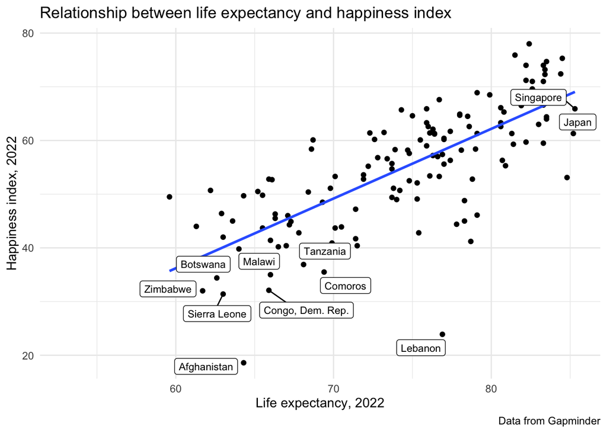

```r
extremes <- for_correlation_wide |>
  filter(life_expectancy_2022 > 85 | happy_value_2022 < 38)

for_correlation_wide |>
  ggplot(aes(x = life_expectancy_2022, y = happy_value_2022)) +
  geom_point() +
  geom_smooth(method = "lm", se = FALSE) +
  ggrepel::geom_label_repel(data = extremes,
                            aes(x = life_expectancy_2022, y = happy_value_2022,
                                label = country),
                            size = 3) +
  theme_minimal() +
  labs(x = "Life expectancy, 2022",
       y = "Happiness index, 2022",
       title = "Relationship between life expectancy and happiness index",
       caption = "Data from Gapminder")
```